# Predicting how barbell lifts are performed

A. Rivera

9/27/2015

## Introduction

Using devices such as Jawbone Up, Nike FuelBand, and Fitbit it is now possible to collect a large amount of data about personal activity relatively inexpensively. These type of devices are part of the quantified self movement – a group of enthusiasts who take measurements about themselves regularly to improve their health, to find patterns in their behavior, or because they are tech geeks. One thing that people regularly do is quantify how much of a particular activity they do, but they rarely quantify how well they do it.

In this project data from accelerometers on the belt, forearm, arm, and dumbell of 6 participants will be used to predict the manner in which they did the exercise they did. They were asked to perform barbell lifts correctly and incorrectly in 5 different ways. More information is available from the website here: http://groupware.les.inf.puc-rio.br/har (see the section on the Weight Lifting Exercise Dataset).

The result will correspond to the variable *classe* in the training data set and will have the following values:

- Class A: exactly according to the specification
- Class B: throwing the elbows to the front
- Class C: lifting the dumbbell only halfway
- Class D: lowering the dumbbell only halfway
- Class E: throwing the hips to the front

Read more: http://groupware.les.inf.puc-rio.br/har#weight_lifting_exercises#ixzz3mxEMRhFr

## Data

The training data for this project are available here:

https://d396qusza40orc.cloudfront.net/predmachlearn/pml-training.csv

The test data are available here:

https://d396qusza40orc.cloudfront.net/predmachlearn/pml-testing.csv

The data for this project come from this source: http://groupware.les.inf.puc-rio.br/har.

## Getting and cleaning the data

We will be using two sets, a training set and a testing set that have been already prepared:

```r
training <- read.csv("https://d396qusza40orc.cloudfront.net/predmachlearn/pml-training.csv",
                        na.strings = c("NA","#DIV/0!",""))
testing <- read.csv("https://d396qusza40orc.cloudfront.net/predmachlearn/pml-testing.csv",
                    na.strings = c("NA","#DIV/0!",""))
```

On a first exploration of the data we can see that a lot of the variables contain many NA’s (output not shown for brevity).

```r
summary(training)
```

So we will first try to eliminate those entries that due to its NA values cannot be used for our predictor. Studying the number of rows and the amount of NA values in each one we can see that there are a lot of columns in which almost all values are NA’s.

```r
ncol(training)
nrow(training)
colSums(is.na(training))
```

[output not shown]

There are also some variables that have no impact on the predicted class, such as the name of the participant or the time stamp. We will also eliminate these columns.

```r
names(training)
```

The last step in the cleaning process will take care of variables with near zero variance. These variables do not contribute to the model and can be safely ignored.

*Cleaning the training set*

```r
# Filter by NA
training <- training[, colSums(is.na(training)) == 0]
# Filter by unused variables
training_set <- training[ ,!(names(training) %in% c("X", "user_name", "raw_timestamp_part_1", "raw_timestamp_part_2", "cvtd_timestamp", "new_window", "num_window"))]
# Removing zero covariates
nzv_train <- nearZeroVar(training_set, saveMetrics = TRUE)
nzv_train
training_set <- training_set[, nzv_train$nzv==FALSE]

str(training_set)
```

To have a better idea of how the data looks like we will make a density plot to study the distribution of the data according to the *classe*:

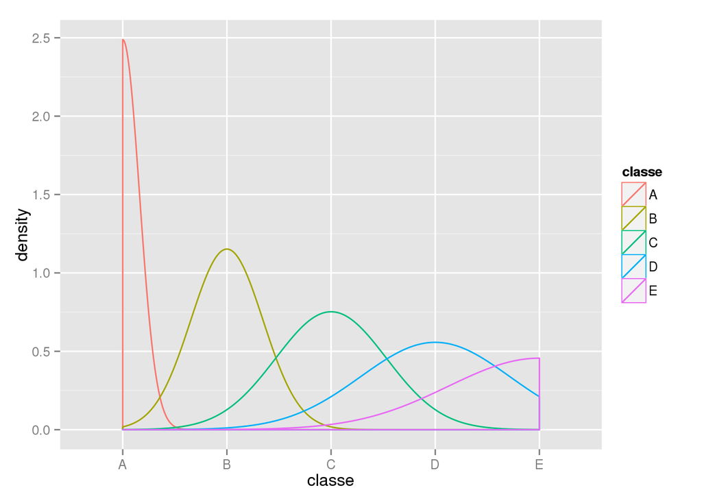

```r
qplot(classe, colour = classe, data = training_set, geom = 'density')
```

## Building the model

The idea is to use the data related to the accelerometers on the belt, forearm, arm, and dumbell. But we can also use any of the other variables to enhance our model. We will first create a model based only on those variables and based on the accuracy and results, we will study the necessity of adding more variables to it.

```r
classe <- training_set$classe
training_acc <- training_set[, colnames(training_set)[grep("*accel*", colnames(training_set))]]
training_acc$classe <- classe
```

Now we will partition these data on a training and testing set to train our model, perform the cross-validation and determine the sample error:

```r
set.seed(2183)
inTrain = createDataPartition(training_acc$classe, p = 0.75, list=FALSE)
trainacc_train <- training_acc[inTrain, ]
trainacc_test <- training_acc[-inTrain, ]
```

The method chosen for our model will be the Random Forest. This method builds a classification bootstrapping samples (for the creation of each tree) and variables (in each split of the tree). It builds multiple trees and in the end a result will be that which gets more votes from all the trees created.

This approach is known to have better accuracy at the risk of slow performance and overfitting.

The out of sample error is estimated during the model building.

```r
modFit <- train(classe ~ ., method="rf", data=trainacc_train,                 trControl=trainControl(method='cv'), allowParallel=TRUE )
```

Note that in this model we specify that the **trainControl (trControl)**, that allows us to control how the model is trained, is *cross-validation*

```r
modFit
```

```
## Random Forest
##
## 14718 samples
##    16 predictors
##     5 classes: 'A', 'B', 'C', 'D', 'E'
##
## No pre-processing
## Resampling: Cross-Validated (10 fold)
## Summary of sample sizes: 13246, 13246, 13246, 13246, 13245, 13247, ...
## Resampling results across tuning parameters:
##
##   mtry  Accuracy   Kappa      Accuracy SD  Kappa SD
##    2    0.9469359  0.9328467  0.006245479  0.007923284
##    9    0.9402765  0.9244277  0.005587593  0.007070135
##   16    0.9258045  0.9061196  0.008890108  0.011260491
##
## Accuracy was used to select the optimal model using  the largest value.
## The final value used for the model was mtry = 2.
```

```r
modFit$finalModel
```

```
##
## Call:
##  randomForest(x = x, y = y, mtry = param$mtry, allowParallel = TRUE)
##                Type of random forest: classification
##                      Number of trees: 500
## No. of variables tried at each split: 2
##
##         OOB estimate of  error rate: 5.2%
## Confusion matrix:
##      A    B    C    D    E class.error
## A 4041   22   54   64    4  0.03440860
## B  111 2616   83   17   21  0.08146067
## C   45   68 2427   21    6  0.05453837
## D   50   10   95 2241   16  0.07089552
## E    5   33   19   21 2628  0.02882483
```

According to this results the model using only the accelerometer data has an **out of sample error of 5.2%**. This seems a bit too high.

```r
confusionMatrix(trainacc_train$classe, modFit$finalModel$predicted)
```

```
## Confusion Matrix and Statistics
##
##           Reference
## Prediction    A    B    C    D    E
##          A 4041   22   54   64    4
##          B  111 2616   83   17   21
##          C   45   68 2427   21    6
##          D   50   10   95 2241   16
##          E    5   33   19   21 2628
##
## Overall Statistics
##
##                Accuracy : 0.948
##                  95% CI : (0.9443, 0.9516)
##     No Information Rate : 0.2889
##     P-Value [Acc > NIR] : < 2.2e-16
##
##                   Kappa : 0.9342
##  Mcnemar's Test P-Value : < 2.2e-16
##
## Statistics by Class:
##
##                      Class: A Class: B Class: C Class: D Class: E
## Sensitivity            0.9504   0.9516   0.9063   0.9480   0.9824
## Specificity            0.9862   0.9806   0.9884   0.9862   0.9935
## Pos Pred Value         0.9656   0.9185   0.9455   0.9291   0.9712
## Neg Pred Value         0.9800   0.9888   0.9793   0.9900   0.9961
## Prevalence             0.2889   0.1868   0.1820   0.1606   0.1818
## Detection Rate         0.2746   0.1777   0.1649   0.1523   0.1786
## Detection Prevalence   0.2843   0.1935   0.1744   0.1639   0.1839
## Balanced Accuracy      0.9683   0.9661   0.9473   0.9671   0.9880
```

As we can see the **accuracy** is: **94.8%**

Now we try using all the variables we had, not only the accelerometer related ones.

```r
inTrainAll = createDataPartition(training_set$classe, p = 0.75, list=FALSE)
train_train <- training_set[inTrainAll,]
train_test <- training_set[-inTrainAll,]
```

```r
modFitAll <- train(classe ~ ., method="rf", data=train_train,                 trControl=trainControl(method='cv'), allowParallel=TRUE )
```

```r
modFitAll
```

```
## Random Forest
##
## 14718 samples
##    52 predictors
##     5 classes: 'A', 'B', 'C', 'D', 'E'
##
## No pre-processing
## Resampling: Cross-Validated (10 fold)
## Summary of sample sizes: 13245, 13246, 13245, 13248, 13248, 13248, ...
## Resampling results across tuning parameters:
##
##   mtry  Accuracy   Kappa      Accuracy SD  Kappa SD
##    2    0.9930702  0.9912332  0.002475820  0.003132993
##   27    0.9930010  0.9911465  0.002028969  0.002566861
##   52    0.9866131  0.9830636  0.003574849  0.004524244
##
## Accuracy was used to select the optimal model using  the largest value.
## The final value used for the model was mtry = 2.
```

```r
modFitAll$finalModel
```

```
##
## Call:
##  randomForest(x = x, y = y, mtry = param$mtry, allowParallel = TRUE)
##                Type of random forest: classification
##                      Number of trees: 500
## No. of variables tried at each split: 2
##
##         OOB estimate of  error rate: 0.67%
## Confusion matrix:
##      A    B    C    D    E class.error
## A 4180    5    0    0    0 0.001194743
## B   19 2823    6    0    0 0.008778090
## C    0   19 2543    5    0 0.009349435
## D    0    0   33 2377    2 0.014510779
## E    0    0    0   10 2696 0.003695492
```

```r
confusionMatrix(train_train$classe, modFitAll$finalModel$predicted)
```

```
## Confusion Matrix and Statistics
##
##           Reference
## Prediction    A    B    C    D    E
##          A 4180    5    0    0    0
##          B   19 2823    6    0    0
##          C    0   19 2543    5    0
##          D    0    0   33 2377    2
##          E    0    0    0   10 2696
##
## Overall Statistics
##
##                Accuracy : 0.9933
##                  95% CI : (0.9918, 0.9945)
##     No Information Rate : 0.2853
##     P-Value [Acc > NIR] : < 2.2e-16
##
##                   Kappa : 0.9915
##  Mcnemar's Test P-Value : NA
##
## Statistics by Class:
##
##                      Class: A Class: B Class: C Class: D Class: E
## Sensitivity            0.9955   0.9916   0.9849   0.9937   0.9993
## Specificity            0.9995   0.9979   0.9980   0.9972   0.9992
## Pos Pred Value         0.9988   0.9912   0.9907   0.9855   0.9963
## Neg Pred Value         0.9982   0.9980   0.9968   0.9988   0.9998
## Prevalence             0.2853   0.1934   0.1754   0.1625   0.1833
## Detection Rate         0.2840   0.1918   0.1728   0.1615   0.1832
## Detection Prevalence   0.2843   0.1935   0.1744   0.1639   0.1839
## Balanced Accuracy      0.9975   0.9947   0.9915   0.9954   0.9992
```

As we can see the **accuracy** is much better too: **99.33%**

Using this last model we apply the model to the set of testing data we created from our clean data set.

```r
prediction <- predict(modFitAll, train_test)
confusionMatrix(prediction, train_test$classe)
```

```
## Confusion Matrix and Statistics
##
##           Reference
## Prediction    A    B    C    D    E
##          A 1394    7    0    0    0
##          B    1  941    5    0    0
##          C    0    1  848   12    0
##          D    0    0    2  792    0
##          E    0    0    0    0  901
##
## Overall Statistics
##
##                Accuracy : 0.9943
##                  95% CI : (0.9918, 0.9962)
##     No Information Rate : 0.2845
##     P-Value [Acc > NIR] : < 2.2e-16
##
##                   Kappa : 0.9928
##  Mcnemar's Test P-Value : NA
##
## Statistics by Class:
##
##                      Class: A Class: B Class: C Class: D Class: E
## Sensitivity            0.9993   0.9916   0.9918   0.9851   1.0000
## Specificity            0.9980   0.9985   0.9968   0.9995   1.0000
## Pos Pred Value         0.9950   0.9937   0.9849   0.9975   1.0000
## Neg Pred Value         0.9997   0.9980   0.9983   0.9971   1.0000
## Prevalence             0.2845   0.1935   0.1743   0.1639   0.1837
## Detection Rate         0.2843   0.1919   0.1729   0.1615   0.1837
## Detection Prevalence   0.2857   0.1931   0.1756   0.1619   0.1837
## Balanced Accuracy      0.9986   0.9950   0.9943   0.9923   1.0000
```

Now we can calculate the out of sample error estimate and check if it is the same we obtained above:

```r
confmatrix <- confusionMatrix(prediction, train_test$classe)$table
prediction2 <- sum(confmatrix[1,1], confmatrix[2,2], confmatrix[3,3], confmatrix[4,4], confmatrix[5,5])
all <- sum(rowSums(confmatrix))
diff_pred <- all - prediction2
oosErrorRate <- (diff_pred / all) * 100
oosErrorRate
```

```
## [1] 0.5709625
```

We get a value of 0.57. This value is quite similar to the one we previously got from the model (0.67).

**Applying the model to the test set**

We can apply this model to the test set we loaded at the beginning of this report:

```r
predict(modFitAll, testing)
```

```
##  [1] B A B A A E D B A A B C B A E E A B B B
## Levels: A B C D E
```